# ggvis

Clément Viguier

17 juillet 2018

## ggvis

This package is an extension of ggplot2 to enable faster design exploration for data visualisation.

For now it contains the custom geom_dash that allows to plot dashes instead of points. Those can be rotated (aes_angle in radiant) or widden (aes_width) to encode additional information in comparison of geom_points.

It also allows distribution visualisation like geom_rug.

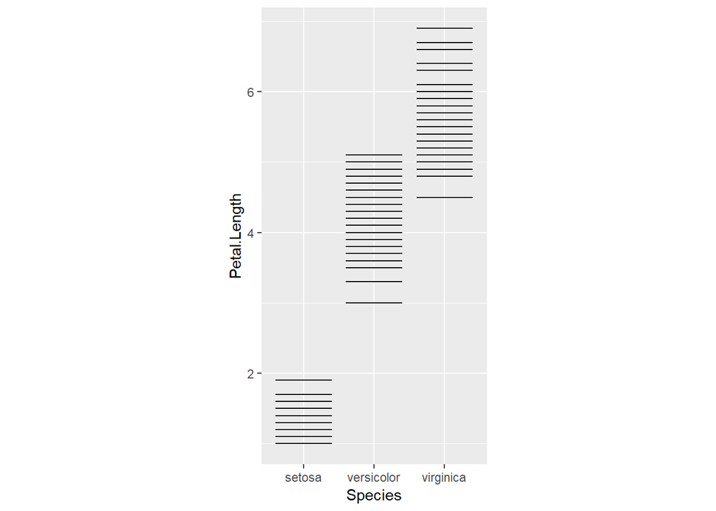

```r
iris %>% ggplot(aes(Species , Petal.Length)) +
  geom_dash(width = 0.8) +
  coord_fixed()
```

An example of the use of `geom_dash` to plot gradient is as follow:

```r
library(data.table)
```

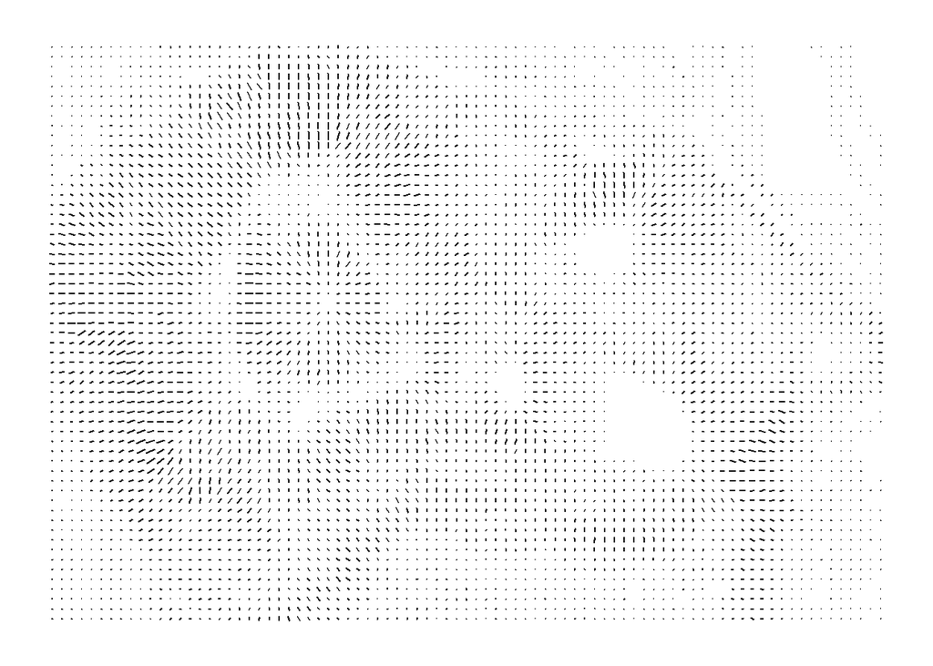

[figure not shown]

```r
library(metR)  # devtools::install_github("eliocamp/metR")

volcano <- as.data.table(melt(volcano, varnames = c("x", "y"),
                              value.name = "h"))
volcano[, c("dx", "dy") := metR::Derivate(h ~ x + y)]
volcano[, "angle" := atan(dy/dx)]
volcano[, "slope" := sqrt(dy^2 + dx^2)]

volcano %>% as.data.frame() %>%  ggplot(aes(x, y)) +
  geom_dash(aes(width = slope/max(slope, na.rm = T), angle = angle), relative = T) +
  coord_fixed()+ theme_void()
```

The geom_arc function allows rapic arc visualisation

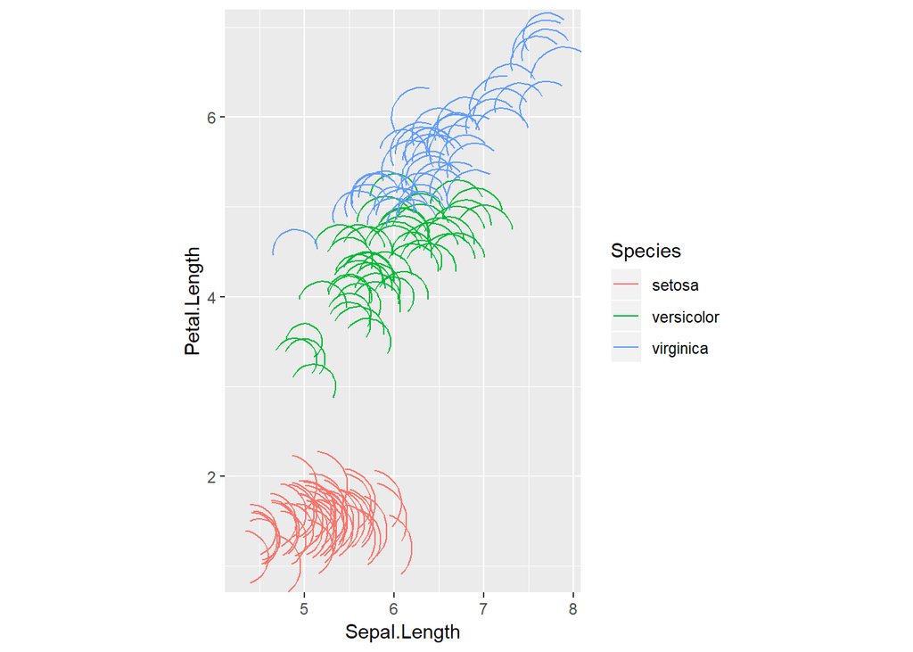

```r
iris %>% ggplot(aes(Sepal.Length , Petal.Length, colour = Species)) +
  geom_arc(width = 0.8, aes(angle = Petal.Width ,radius = 0.1*Sepal.Width)) +
  coord_fixed()
```

Because these geoms do not use symbols, but explicit representation of geometric objects, they work better with fixed coordinates. This can be ensured by addig `+ coord_fixed()` to your ggplot call.

Further work is need to ensure all objects fit the frame of the plot that is currently computed from the x,y of the aesthetic. For now this problem is fixed by increasin the visible area with the function `coord_cartesian()`.